# K1_STAT_multiple_regression

Author

Duc Nguyen

Published

November 8, 2026

[**Tài liệu biên soạn trong chuyên đề R Statistics**](https://www.tuhocr.com/r-statistics)

[**Version final xem ở đây**](https://thongkevavedothi.com/blog/xac-suat-va-thong-ke/K1_STAT_multiple_regression.html)

# 1 Import dataset

```r
library(Countr)
library(tidyverse)
library(lattice)

data("fertility")

fertility -> df

head(df, n = 30)
```

```
   children german years_school voc_train university religion year_birth rural age_marriage
1         2     no            8        no         no Catholic         42   yes           20
2         3     no            8        no         no Catholic         55   yes           21
3         2     no            8        no         no Catholic         51   yes           24
4         4     no            8        no         no Catholic         54    no           26
5         2     no            8        no         no Catholic         46   yes           22
6         2     no            8        no         no Catholic         41    no           18
7         2     no            8        no         no Catholic         50    no           21
8         2     no            8        no         no Catholic         43   yes           21
9         4     no            8        no         no Catholic         50   yes           18
10        2     no            8        no         no Catholic         49   yes           21
11        1     no            8        no         no Catholic         55    no           30
12        3     no            8        no         no Catholic         56    no           22
13        1     no            8        no         no Catholic         47   yes           18
14        2     no            8        no         no Catholic         45   yes           24
```

[output cut: 16 more lines]

# 2 Check dataset

```r
dim(df)
```

```
[1] 1243    9
```

```r
str(df)
```

```
'data.frame':   1243 obs. of  9 variables:
 $ children    : int  2 3 2 4 2 2 2 2 4 2 ...
 $ german      : Factor w/ 2 levels "no","yes": 1 1 1 1 1 1 1 1 1 1 ...
 $ years_school: int  8 8 8 8 8 8 8 8 8 8 ...
 $ voc_train   : Factor w/ 2 levels "no","yes": 1 1 1 1 1 1 1 1 1 1 ...
 $ university  : Factor w/ 2 levels "no","yes": 1 1 1 1 1 1 1 1 1 1 ...
 $ religion    : Factor w/ 4 levels "Catholic","Muslim",..: 1 1 1 1 1 1 1 1 1 1 ...
 $ year_birth  : int  42 55 51 54 46 41 50 43 50 49 ...
 $ rural       : Factor w/ 2 levels "no","yes": 2 2 2 1 2 1 1 2 2 2 ...
 $ age_marriage: int  20 21 24 26 22 18 21 21 18 21 ...
```

```r
names(df)
```

```
[1] "children"     "german"       "years_school" "voc_train"    "university"   "religion"     "year_birth"
[8] "rural"        "age_marriage"
```

```r
library(table1)
library(flextable)
library(magrittr)
library(openxlsx)
library(dplyr)

table_freq <- table1:::table1.formula( ~ . | german,
                     topclass="Rtable1-grid",
                     data = df,
                    # digits = 4,
                    render.continuous = c("Mean (± SD)" = "MEAN (± SD)",
                                          "Median [Min, Max]" = "MEDIAN [MIN, MAX]")
                          )

table_freq
```

|  | no (N=245) | yes (N=998) | Overall (N=1243) |
| --- | --- | --- | --- |
| children |  |  |  |
| Mean (± SD) | 3.17 (± 1.88) | 2.19 (± 1.36) | 2.38 (± 1.53) |
| Median [Min, Max] | 3.00 [0, 10.0] | 2.00 [0, 11.0] | 2.00 [0, 11.0] |
| years_school |  |  |  |
| Mean (± SD) | 8.08 (± 0.502) | 9.35 (± 0.860) | 9.10 (± 0.948) |
| Median [Min, Max] | 8.00 [8.00, 13.0] | 9.00 [8.00, 13.0] | 9.00 [8.00, 13.0] |
| voc_train |  |  |  |
| no | 217 (88.6%) | 487 (48.8%) | 704 (56.6%) |
| yes | 28 (11.4%) | 511 (51.2%) | 539 (43.4%) |
| university |  |  |  |
| no | 242 (98.8%) | 965 (96.7%) | 1207 (97.1%) |
| yes | 3 (1.2%) | 33 (3.3%) | 36 (2.9%) |
| religion |  |  |  |
| Catholic | 74 (30.2%) | 56 (5.6%) | 130 (10.5%) |
| Muslim | 93 (38.0%) | 409 (41.0%) | 502 (40.4%) |
| Other | 75 (30.6%) | 0 (0%) | 75 (6.0%) |
| Protestant | 3 (1.2%) | 533 (53.4%) | 536 (43.1%) |
| year_birth |  |  |  |
| Mean (± SD) | 47.5 (± 5.42) | 53.1 (± 9.06) | 52.0 (± 8.76) |
| Median [Min, Max] | 47.0 [40.0, 73.0] | 52.0 [40.0, 83.0] | 50.0 [40.0, 83.0] |
| rural |  |  |  |
| no | 122 (49.8%) | 491 (49.2%) | 613 (49.3%) |
| yes | 123 (50.2%) | 507 (50.8%) | 630 (50.7%) |
| age_marriage |  |  |  |
| Mean (± SD) | 22.2 (± 3.48) | 23.3 (± 2.91) | 23.1 (± 3.06) |
| Median [Min, Max] | 22.0 [17.0, 30.0] | 23.0 [17.0, 30.0] | 23.0 [17.0, 30.0] |

# 3 Chuyển biến factor cho các biến binary

```r
df$german <- factor(df$german,
                    levels = c("no", "yes"))

df$voc_train <- factor(df$voc_train,
                       levels = c("no", "yes"))

df$university <- factor(df$university,
                       levels = c("no", "yes"))

df$rural <- factor(df$rural,
                   levels = c("no", "yes"))

df$religion <- factor(df$religion,
                   levels = c("Catholic", "Muslim", "Protestant", "Other"))
```

# 4 Vẽ đồ thị correlation

Việc tạo các đối tượng `df` khác nhau giúp tách ra các luồng xử lý dataset độc lập không bị ảnh hưởng khi cần biến đổi dữ liệu.

```r
dg <- df

df -> df_ori # lưu lại dataset gốc để phục hồi khi cần
```

```r
dg$german <- as.numeric(dg$german) - 1
# german: no = 0
# german: yes = 1

dg$voc_train <- as.numeric(dg$voc_train) - 1
# voc_train: no = 0
# voc_train: yes = 1

dg$university <- as.numeric(dg$university) - 1
# university: no = 0
# university: yes = 1

dg$rural <- as.numeric(dg$rural) - 1
# rural: no = 0
# rural: yes = 1
```

```r
png(filename = "cor.png",
    width = 9,
    height = 9,
    units = "in",
    res = 300)

source("https://applyr.netlify.app/blog/chart.Correlation_check.R")

chart.Correlation_check(
R = dg[ , -6], # bỏ cột religion vì là character
histogram = TRUE,
method = "pearson",
cex_text = 3,
cex_sign = 3
)

dev.off()
```

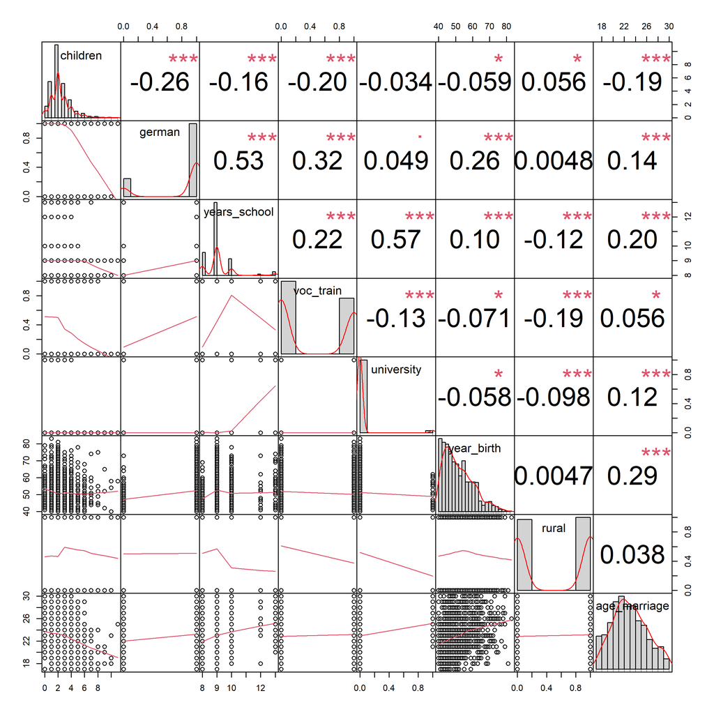

## 4.1 Kiểm tra `children` và `german`

```r
aggregate(children ~ german,
          data = df,
          FUN = mean)
```

```
  german children
1     no 3.171429
2    yes 2.190381
```

# 5 Simple regression

$$Y = \beta_0 + \beta_1 \times X_1 + \epsilon$$

## 5.1 Y numeric | X numeric

$$\text{children} = 4.53090 - 0.09291 \times \text{age\_marriage}$$

```r
m1 <- lm(children ~ age_marriage,
          data = df)

summary(m1)
```

```
Call:
lm(formula = children ~ age_marriage, data = df)

Residuals:
    Min      1Q  Median      3Q     Max
-2.9514 -0.8585 -0.3010  0.6990  8.7919

Coefficients:
             Estimate Std. Error t value Pr(>|t|)
(Intercept)   4.53090    0.32452  13.962  < 2e-16 ***
age_marriage -0.09291    0.01392  -6.674 3.74e-11 ***
---
Signif. codes:  0 '***' 0.001 '**' 0.01 '*' 0.05 '.' 0.1 ' ' 1

Residual standard error: 1.5 on 1241 degrees of freedom
Multiple R-squared:  0.03465,   Adjusted R-squared:  0.03387
F-statistic: 44.54 on 1 and 1241 DF,  p-value: 3.744e-11
```

```r
m1_p2 <- lm(children ~ poly(age_marriage, 2, raw = TRUE),
          data = df)

summary(m1_p2)
```

```
Call:
lm(formula = children ~ poly(age_marriage, 2, raw = TRUE), data = df)

Residuals:
    Min      1Q  Median      3Q     Max
-3.3651 -1.0706 -0.1835  0.7243  8.8830

Coefficients:
                                    Estimate Std. Error t value Pr(>|t|)
(Intercept)                        11.448327   2.126798   5.383 8.76e-08 ***
poly(age_marriage, 2, raw = TRUE)1 -0.692719   0.182798  -3.790 0.000158 ***
poly(age_marriage, 2, raw = TRUE)2  0.012779   0.003883   3.291 0.001027 **
---
Signif. codes:  0 '***' 0.001 '**' 0.01 '*' 0.05 '.' 0.1 ' ' 1

Residual standard error: 1.494 on 1240 degrees of freedom
Multiple R-squared:  0.04301,   Adjusted R-squared:  0.04146
F-statistic: 27.86 on 2 and 1240 DF,  p-value: 1.458e-12
```

Khi độ tuổi kết hôn tăng lên 1 đơn vị thì số trẻ trung bình mà người phụ nữ sinh ra sẽ giảm đi -0.092 đơn vị.

### 5.1.1 Cách tính phần dư

```r
y_pred <- coef(m1)[1] + coef(m1)[2]*df$age_marriage

y_fit <- fitted(m1)
names(y_fit) <- NULL

identical(round(y_pred, 10), round(y_fit, 10))
```

```
[1] TRUE
```

```r
y_res <- df$children - y_pred

# y_res

m1_res <- resid(m1)
names(m1_res) <- NULL

identical(y_res, m1_res)
```

```
[1] FALSE
```

```r
y_res[1:10]
```

```
 [1] -0.6726523  0.4202602 -0.3010023  1.8848227 -0.4868273 -0.8584773 -0.5797398 -0.5797398  1.1415227 -0.5797398
```

```r
m1_res[1:10]
```

```
 [1] -0.6726523  0.4202602 -0.3010023  1.8848227 -0.4868273 -0.8584773 -0.5797398 -0.5797398  1.1415227 -0.5797398
```

```r
identical(round(y_res, 10), round(m1_res, 10))
```

```
[1] TRUE
```

```r
df$y_pred <- fitted(m1)
df$residual <- resid(m1)
```

### 5.1.2 Effect plot

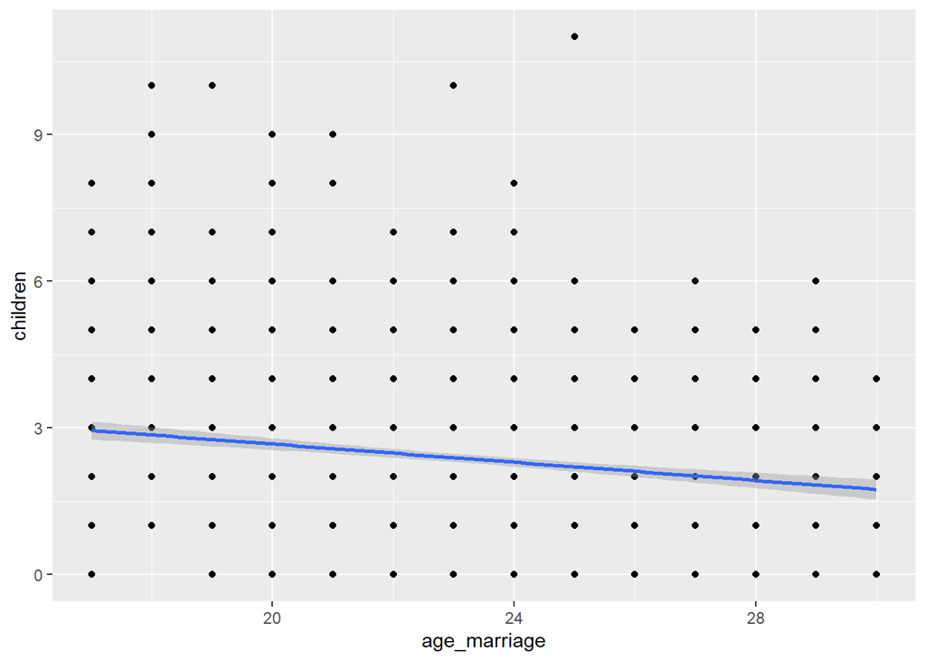

```r
library(ggplot2)

ggplot(data = df,
       mapping = aes(x = age_marriage,
                     y = children)) +

  geom_point() +

  geom_smooth(method = "lm")
```

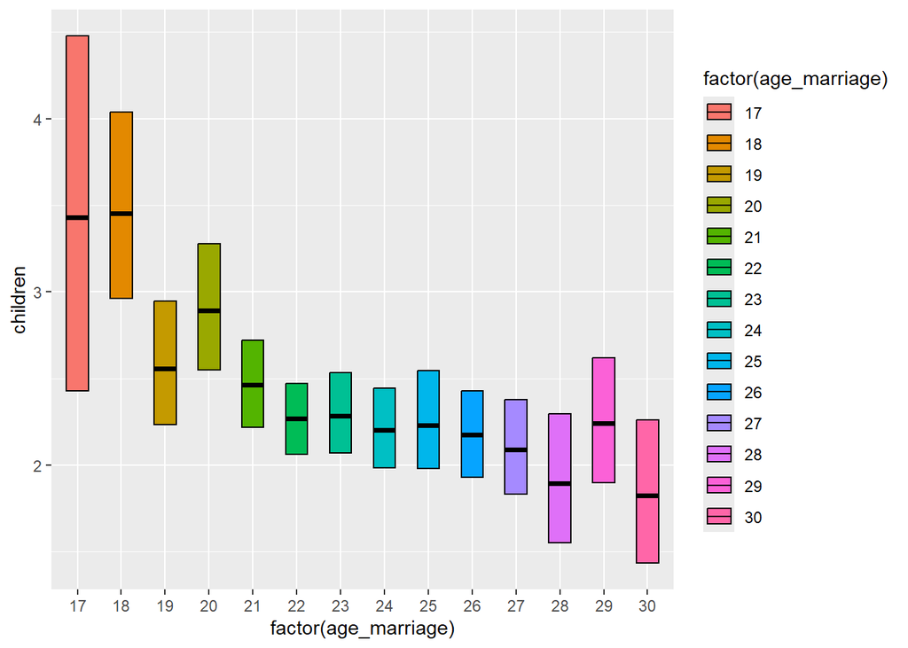

```r
library(ggplot2)
library(Hmisc)
ggplot(data = df,
       mapping = aes(x = factor(age_marriage),
                     y = children)) +

  # geom_boxplot() +

  stat_summary(fun.data = mean_cl_boot,
               geom ='crossbar',
               width = 0.5,
               aes(fill = factor(age_marriage)),
               position = position_dodge2(padding = 0.3))
```

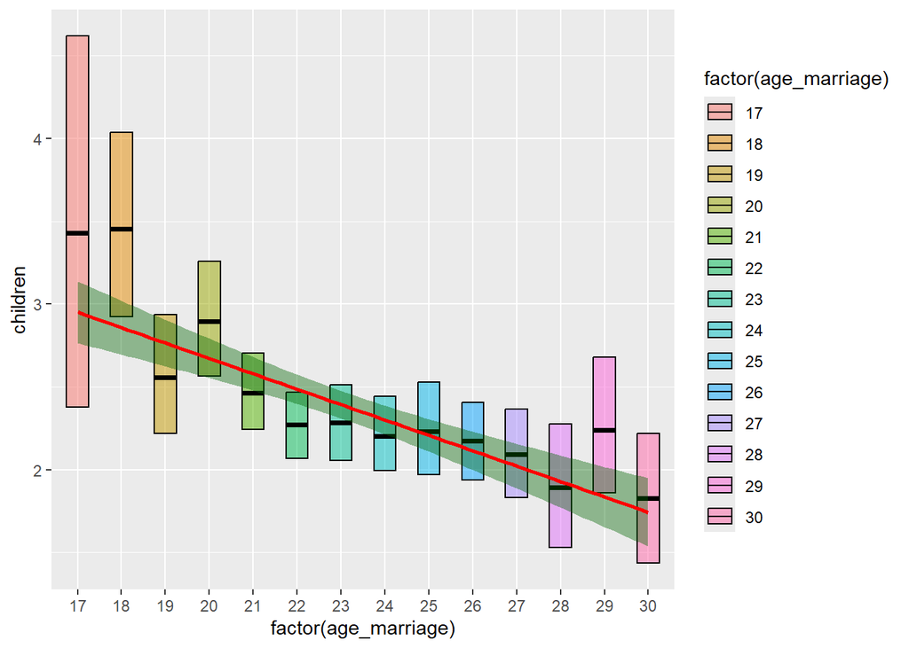

```r
library(ggplot2)
library(Hmisc)
ggplot() +

  # geom_boxplot() +

  stat_summary(data = df,
               mapping = aes(x = factor(age_marriage),
                             y = children,
                             fill = factor(age_marriage)),
               fun.data = mean_cl_boot,
               geom ='crossbar',
               width = 0.5,
               position = position_dodge2(padding = 0.3),
               alpha = 0.5) +

  geom_smooth(data = df,
       mapping = aes(x = as.numeric(factor(age_marriage)),
                     y = children),
       fill = "darkgreen",
       color = "red",
       method = "lm")
```

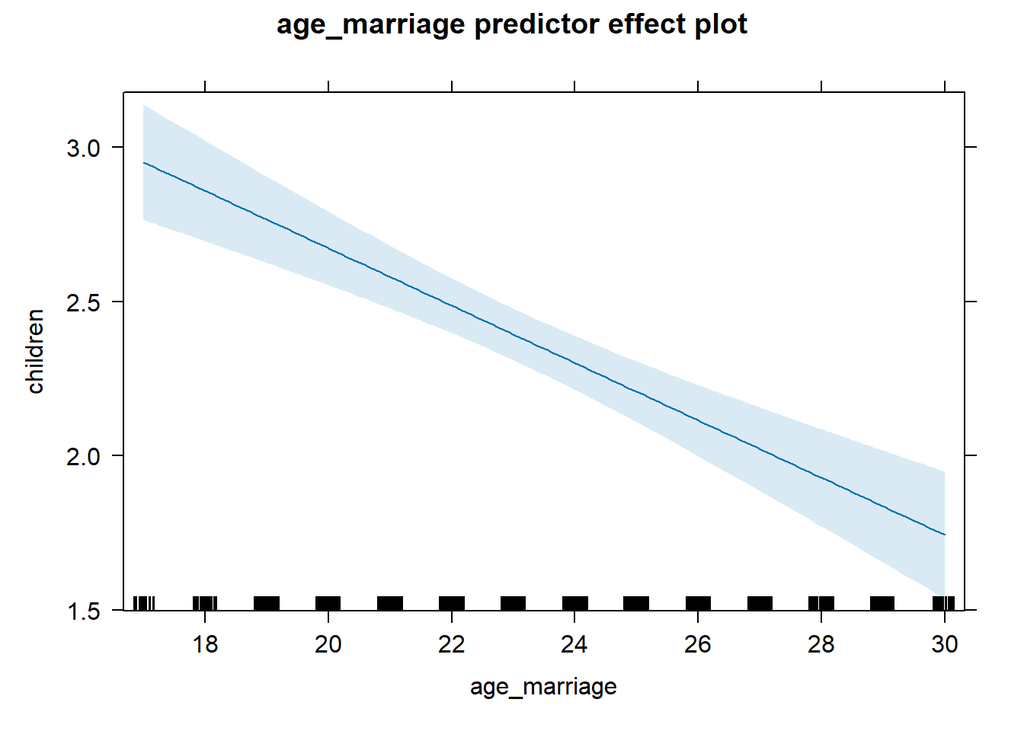

```r
library(effects)

# plot(predictorEffects(m1, ~ age_marriage))

# par(mfrow = c(2,1))

effects:::plot.efflist(predictorEffects(m1, ~ age_marriage))
```

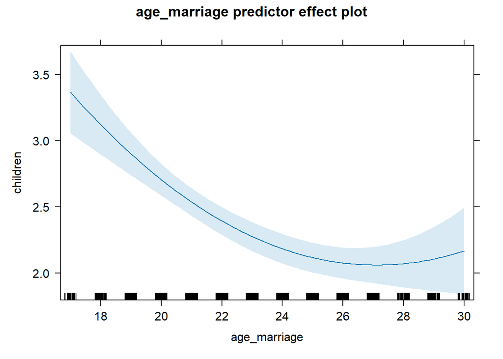

```r
effects:::plot.efflist(predictorEffects(m1_p2, ~ age_marriage))
```